# Wine Quality Challenge

### Scatterplots

With the following scatterplots, we can see the relationship between the quality and the other features. Each level of quality is represented by a different color.

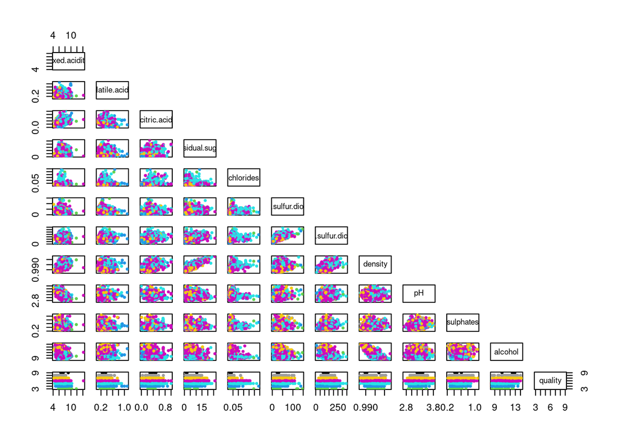

```r
# Scatterplot matrix, with different colors for each quality level
pairs(train, col = train$quality, upper.panel = NULL, pch = 19, cex = 0.5)
```

```r
# Single scatterplots of features against quality
# plot(train$alcohol, train$quality, col = train$quality, pch = 19, cex = 0.5)
# plot(train$total.sulfur.dioxide, train$quality, col = train$quality, pch = 19, cex = 0.5)
# plot(train$free.sulfur.dioxide, train$quality, col = train$quality, pch = 19, cex = 0.5)
# plot(train$volatile.acidity, train$quality, col = train$quality, pch = 19, cex = 0.5)
# plot(train$fixed.acidity, train$quality, col = train$quality, pch = 19, cex = 0.5)
# plot(train$pH, train$quality, col = train$quality, pch = 19, cex = 0.5)
# plot(train$density, train$quality, col = train$quality, pch = 19, cex = 0.5)
# plot(train$sulphates, train$quality, col = train$quality, pch = 19, cex = 0.5)
# plot(train$chlorides, train$quality, col = train$quality, pch = 19, cex = 0.5)
# plot(train$residual.sugar, train$quality, col = train$quality, pch = 19, cex = 0.5)
# plot(train$citric.acid, train$quality, col = train$quality, pch = 19, cex = 0.5)
```

### Principal Component Analysis

Here, PCA is used to identify the most important features in the dataset in order to better understand the data. The biplot shows the relationship between the features and the quality of the wine. By default, the prcomp() function, with the option “scale = true”, centers and scales the data, so we don’t need to do it manually.

```r
# Principal Component Analysis
pca <- prcomp(train[,1:12], scale = TRUE)
summary(pca)
```

```
## Importance of components:
##                           PC1    PC2    PC3     PC4     PC5    PC6     PC7
## Standard deviation     1.8464 1.2644 1.1729 1.04298 0.98962 0.9436 0.85827
## Proportion of Variance 0.2841 0.1332 0.1147 0.09065 0.08161 0.0742 0.06139
## Cumulative Proportion  0.2841 0.4173 0.5320 0.62262 0.70423 0.7784 0.83981
##                            PC8     PC9   PC10    PC11    PC12
## Standard deviation     0.85045 0.75484 0.5786 0.52941 0.11907
## Proportion of Variance 0.06027 0.04748 0.0279 0.02336 0.00118
## Cumulative Proportion  0.90008 0.94757 0.9755 0.99882 1.00000
```

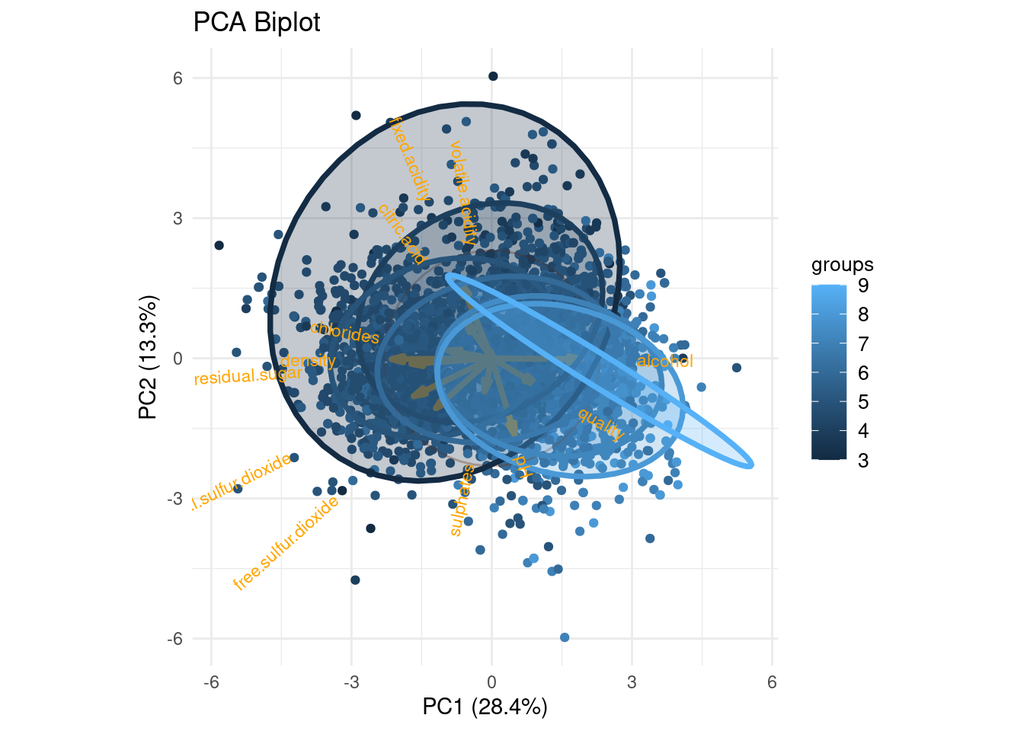

```r
# Biplot with GGplot2
ggbiplot::ggbiplot(pca, obs.scale = 1, var.scale = 1, groups = train$quality, ellipse = TRUE, circle = TRUE, varname.size = 3, varname.adjust = 3, varname.color = "orange", varname.face = "bold") +
  theme_minimal() +
  theme(legend.title = element_text(size = 10), legend.text = element_text(size = 10)) +
  ggtitle("PCA Biplot")
```

### Correlation heatmap

The correlation heatmap shows the correlation between the features. The correlation matrix is calculated using the cor() function, and the heatmap is plotted using the corrplot() function. In this dataset, alcohol, density, chlorides, and volatile acidity are the most correlated features with quality.

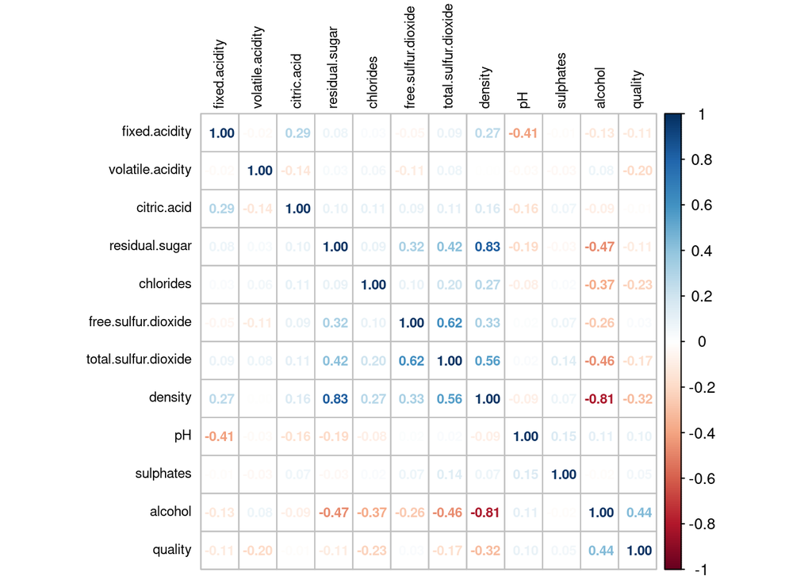

```r
corrplot(cor(train[,1:12]), method = "number", tl.col = "black", tl.cex = 0.7, number.cex = 0.7)
```